# NetCoMi

Camilo

2022-07-01

## Analysis with NetCoMi

Install packages:

```r
install.packages("devtools")
install.packages("BiocManager")
install.packages("WGCNA")
install.packages("qgraph")
install.packages("NetCoMi")


# Install NetCoMi
devtools::install_github("stefpeschel/NetCoMi",
                         dependencies = c("Depends", "Imports", "LinkingTo"),
                         repos = c("https://cloud.r-project.org/",
                                   BiocManager::repositories()))

devtools::install_github("GraceYoon/SPRING", force = TRUE)
devtools::install_github("zdk123/SpiecEasi", force = TRUE)

install.packages("remotes")
remotes::install_github("stefpeschel/NetCoMi", force = TRUE)
```

Load libraries:

```r
library(WGCNA)
library(NetCoMi)
```

Tratamos los datos del tutorial

```r
data("amgut1.filt")
data("amgut2.filt.phy")
```

Algunas consideraciones de los comandos a tomar en cuenta:  
Especificaciones de los comandos:

- netConstruct(). Sirve para filtrar los datos de la red
- filtSamp. Solo se incluyen muestras con un número total de lecturas ejemplo: de al menos 1000
- filtTax. El comando manada a llamar solo al #NUMERO DE TAXONES CON MAYOR FRECUENCIA EJEMPLO: MAYOR A 50
- measure. Define la medida de asociación o disimilitud, que es “spring”en nuestro caso.
- measurePar. nlambday rep.numse Establecen en 10 para reducir el tiempo de ejecución, pero deberían ser más altos para datos reales.

La normalización, así como el manejo de cero, se realizan internamente en SPRING().  
Por lo tanto, establecemos normMethody zeroMethodpara “none”.  
Además, configuramos porque sparsMethod = “none” devuelve una red dispersa en la que no es necesario ningún paso de dispersión adicional.

- dissFunc. Este comando es para seleccionar si la red va ser firmada, no firmada o hibrida (signed, unsigned, hybrid) en el ejemplo si realiza dissFunc = “signed” ——firmado

El argumento: verbose se establece en 3 para que netConstruct() se impriman todos los mensajes generados por funciones externas verbose = 3

```r
net_single <- netConstruct(amgut1.filt,
                           filtTax = "highestFreq",
                           filtTaxPar = list(highestFreq = 50),
                           filtSamp = "totalReads",
                           filtSampPar = list(totalReads = 1000),
                           measure = "spring",
                           measurePar = list(nlambda=10,
                                             rep.num=10),
                           normMethod = "none",
                           zeroMethod = "none",
                           sparsMethod = "none",
                           dissFunc = "signed",
                           verbose = 3,
                           seed = 123456)
```

```
## Data filtering ...
```

```
## 77 taxa removed.
```

```
## 50 taxa and 289 samples remaining.
```

```
##
## Calculate 'spring' associations ...
```

[output not shown]

```
## Done.
```

## Analizando la red construida

- netAnalyze(). Sirve para analizar la red construida, algunas metricas que da el resultado es:  
  comandos:
- centrLCC. ——–se establece en el TRUE significado de que las centralidades se calculan solo para los nodos en el componente conectado más grande (LCC).
- cluster_fast_greedy(). ——Los clústeres se identifican mediante la optimización de la modularidad codiciosa, toma en cuenta la función igraph
- hubPar. —– esta función nos da los nodos hub o nodos concentradores. Los concentradores son nodos con un valor de centralidad de vector propio por encima del cuantil empírico del 95 % de todas las centralidades de vector propio en la red  
  weightDeg y normDegestán estan configurados para FALSE que el grado de un nodo se defina simplemente como el número de nodos que son adyacentes al nodo.

```r
props_single <- netAnalyze(net_single,
                           centrLCC = TRUE,
                           clustMethod = "cluster_fast_greedy",
                           hubPar = "eigenvector",
                           weightDeg = FALSE, normDeg = FALSE)

#?summary.microNetProps
summary(props_single, numbNodes = 5L)
```

`````````````````````````````````
##
## Component sizes
## ```````````````
## size: 48 1
##    #:  1 2
## ______________________________
## Global network properties
## `````````````````````````
## Largest connected component (LCC):
##
## Relative LCC size         0.96000
## Clustering coefficient    0.33595
## Modularity                0.53407
## Positive edge percentage 88.34951
## Edge density              0.09131
## Natural connectivity      0.02856
## Vertex connectivity       1.00000
## Edge connectivity         1.00000
## Average dissimilarity*    0.97035
## Average path length**     2.36877
##
## Whole network:
##
## Number of components      3.00000
## Clustering coefficient    0.33595
## Modularity                0.53407
## Positive edge percentage 88.34951
## Edge density              0.08408
## Natural connectivity      0.02714
##
##  *Dissimilarity = 1 - edge weight
## **Path length: Units with average dissimilarity
##
## ______________________________
## Clusters
## - In the whole network
## - Algorithm: cluster_fast_greedy
## ````````````````````````````````
##
## name: 0  1  2  3 4 5
`````````````````````````````````

[output cut: 32 more lines]

```
## Closeness centrality (normalized):
##
## 288134 0.68431
## 311477 0.68417
## 199487 0.68108
## 302160 0.67528
## 188236 0.66867
##
## Eigenvector centrality (normalized):
##
## 288134 1.00000
## 311477 0.94406
## 190597 0.90806
## 199487 0.85436
## 188236 0.72730
```

## Visualización de la red

Lo que se pretende realizar en este paso visualizar nuestra red de manera visual, utilizando nodos y aristas Usamos los grupos determinados como colores de nodo y escalamos los tamaños de nodo de acuerdo con la centralidad del vector propio del nodo.

```r
# help page
# ?plot.microNetProps

sizeGrWindow(9, 5)
par(mfrow = c(1,2));
cex1 = 0.9;

p <- plot(props_single,
          nodeColor = "cluster",
          nodeSize = "eigenvector",
          title1 = "Network on OTU level with SPRING associations",
          showTitle = TRUE,
          cexTitle = 2.3)

legend(0.7, 1.1, cex = 2.2, title = "estimated association:",
       legend = c("+","-"), lty = 1, lwd = 3, col = c("#009900","red"),
       bty = "n", horiz = TRUE)

p$q1$Arguments$cut
```

[output not shown]

```
##       75%
## 0.3367287
```

## Red única con correlación de Pearson como medida de asociación

```r
net_single2 <- netConstruct(amgut2.filt.phy,
                            measure = "pearson",
                            normMethod = "clr",
                            zeroMethod = "multRepl",
                            sparsMethod = "threshold",
                            thresh = 0.3,
                            verbose = 3)
```

```
## 2 rows with zero sum removed.
```

```
## 138 taxa and 294 samples remaining.
```

```
##
## Zero treatment:
```

```
## Execute multRepl() ...
```

```
## Done.
##
## Normalization:
## Execute clr(){SpiecEasi} ... Done.
##
## Calculate 'pearson' associations ... Done.
##
## Sparsify associations via 'threshold' ... Done.
```

## Análisis y visualización de redes

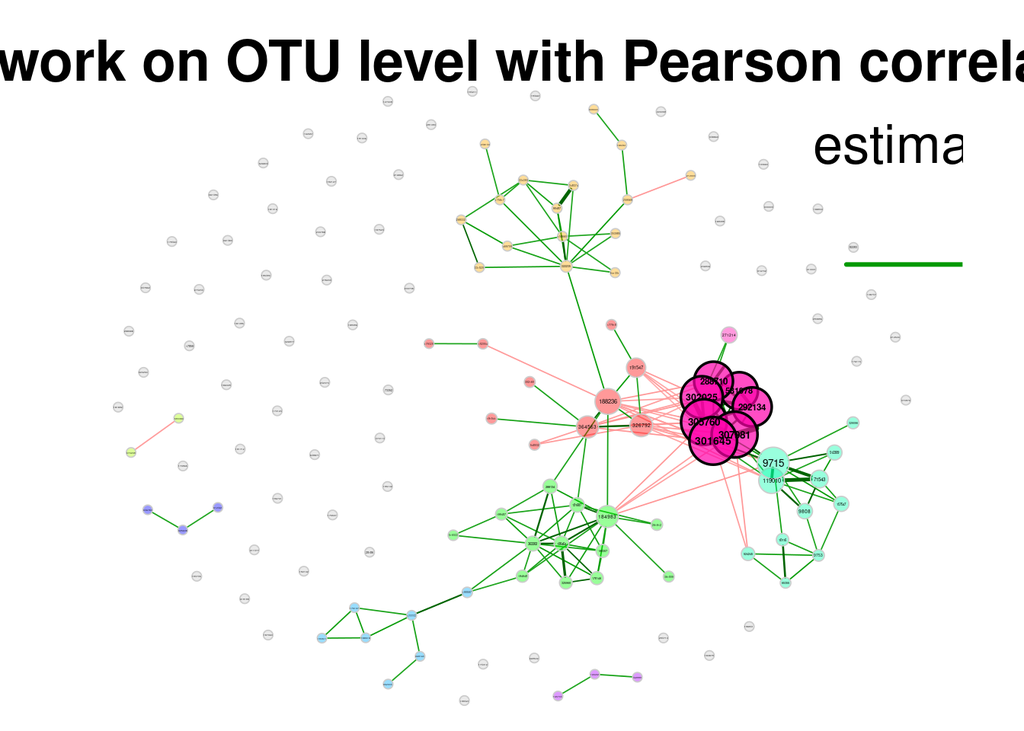

```r
props_single2 <- netAnalyze(net_single2, clustMethod = "cluster_fast_greedy")

plot(props_single2,
     nodeColor = "cluster",
     nodeSize = "eigenvector",
     title1 = "Network on OTU level with Pearson correlations",
     showTitle = TRUE,
     cexTitle = 2.3)

legend(0.7, 1.1, cex = 2.2, title = "estimated correlation:",
       legend = c("+","-"), lty = 1, lwd = 3, col = c("#009900","red"),
       bty = "n", horiz = TRUE)
```

## Mejorando la visualización de la red para que se vea mas estetica y la infoamci`ón sea mas facil de procesar

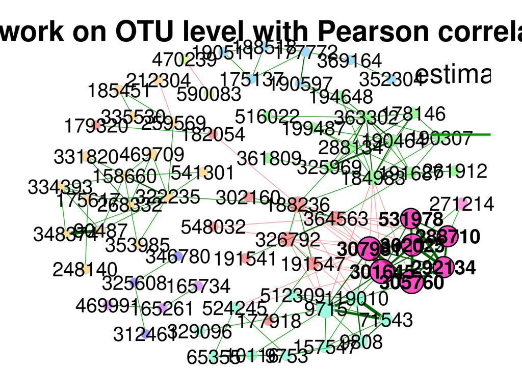

```r
plot(props_single2,
     nodeColor = "cluster",
     nodeSize = "eigenvector",
     repulsion = 0.8,
     rmSingles = TRUE,
     labelScale = FALSE,
     cexLabels = 1.6,
     nodeSizeSpread = 3,
     cexNodes = 2,
     title1 = "Network on OTU level with Pearson correlations",
     showTitle = TRUE,
     cexTitle = 2.3)

legend(0.7, 1.1, cex = 2.2, title = "estimated correlation:",
       legend = c("+","-"), lty = 1, lwd = 3, col = c("#009900","red"),
       bty = "n", horiz = TRUE)
```